# Data Cleaning

```r
library(tidyverse)
library(lubridate)
```

# File Descriptions

### Demographic

- `population_2019.RDS` contains the population for each fips code
- `statecodes.csv` contains state names mapped to codes from [the census](https://www2.census.gov/programs-surveys/popest/datasets/2010-2019/counties/totals/)
- `county_fips.tsv` contains fips code mapped to county name and state
- `state_pop.RDS` contains state population estimates from [the census](https://www2.census.gov/programs-surveys/popest/datasets/2010-2019/state/detail/)

### Covidestim

- `covidestim_original_all.RDS` is an RDS file of the covidestim csv from the link `https://covidestim.s3.us-east-2.amazonaws.com/latest/state/estimates.csv`, unmodified; includes dates through 2021 earlier than 2021-12-02
- `covidestim_last_weeks_all_states.RDS` contains estimates after 2021-12-02 from `https://api2.covidestim.org/latest_runs?geo_type=eq.state&select=*,timeseries(*)`
- `covidestim_biweekly_all_states.RDS` is the cases summed for each 2-week interval, including data from `https://covidestim.s3.us-east-2.amazonaws.com/latest/state/estimates.csv` to obtain dates before 2021-12-02 (latest date available is 2021-11-30) and data from `https://api2.covidestim.org/latest_runs?geo_type=eq.state&select=*,timeseries(*)` to obtain dates after 2021-12-02
- `covidestim_county_estimates.RDS` contains estimates of infections by date and fips from `https://covidestim.s3.us-east-2.amazonaws.com/latest/estimates.csv`, no modifications other than selecting variables of interest
- `covidestim_biweekly_all_counties.RDS` contains biweekly aggregates for all counties, data again from link `https://covidestim.s3.us-east-2.amazonaws.com/latest/estimates.csv`

### State-level

- `tests_daily_all_states.RDS` contains daily test results by date and state from the healthdata.gov endpoint [here](https://healthdata.gov/dataset/COVID-19-Diagnostic-Laboratory-Testing-PCR-Testing/j8mb-icvb)
- `tests_biweekly_all_states.RDS` contains test results aggregated by two-week interval for each state

### County-level

- MA:
  - `ma/archived_webpage_mass_cases.html` is the webpage [here](https://www.mass.gov/info-details/archive-of-covid-19-cases-in-massachusetts) downloaded February 18, 2023. This page contains links to access the county-level data in Massachusetts.
  - `ma_county_original.RDS` contains the original county-level data in Massachusetts downloaded from a link on this page
  - `ma_county_biweekly` contains data aggregated by two-week interval by county
- MI:
  - `mi_county_original.RDS` contains the original county-level data in Michigan downloaded from the government website [here](https://www.michigan.gov/coronavirus/stats)
  - `mi_county_daily.RDS` contains daily data with small cleaning modifications from the original for clarity
  - `mi_county_biweekly.RDS.RDS` contains data aggregated by two-week interval by county

### Hospitalizations

- `hosp_biweekly_all_states.RDS` is biweekly hospitalizations by state, accessible [here](https://dev.socrata.com/foundry/healthdata.gov/g62h-syeh)
- `hosp_biweekly_all_counties.RDS` is biweekly hospitalizations by county, aggregated using functionality provided by [Covidestim](https://github.com/covidestim/covidestim-sources#user-content-fn-1-6778941a67ce95d7bd5fda0b62f3b0d7)
  - `hhs-hospitalizations-by-county.RDS` is the original file from Covidestim containing weekly counts of a collection of variables related to hospitalization

```r
# STRUCTURE: fips, state, week, negative, positive, total, posrate

data_path <- paste0(here::here(), "/data/")


########################################
#CENSUS DATA POPULATION ESTIMATES
########################################
url_2019 <- "https://www2.census.gov/programs-surveys/popest/datasets/2010-2019/counties/totals/co-est2019-alldata.csv"

population_2019 <- read_csv(url_2019) %>%
  mutate(fips_code = paste0(STATE, COUNTY)) %>%
  select(fips_code, population =POPESTIMATE2019)

population_2019 %>%
  head()
```

| fips_code | population |
| --- | --- |
| 01000 | 4903185 |
| 01001 | 55869 |
| 01003 | 223234 |
| 01005 | 24686 |
| 01007 | 22394 |
| 01009 | 57826 |

```r
saveRDS(population_2019,
        paste0(here::here(),
        "/data/demographic/population_2019.RDS"))
```

# Covidestim

## Covidestim All States (State-level)

Due to changes in the model to handle the Omicron wave, we have to obtain dates before 2021-12-02 from a different source than the latest runs endpoint of the API.

```r
# set end date
end_date <- ymd("2022-02-25")
```

```r
########################################
# COVIDESTIM BIWEEKLY DATA ALL STATES
########################################

covidestim_api_link <- "https://api2.covidestim.org/latest_runs?geo_type=eq.state&select=*,timeseries(*)"
covidestim <- httr::GET(covidestim_api_link)


# only go to the 6th because these are already weekly counts
# get the last couple weeks of 2021
last_weeks <-jsonlite::fromJSON(
  httr::content(covidestim,
                as = "text",
                encoding = "UTF-8"),
  simplifyVector = TRUE,
  flatten = TRUE)  %>%
  unnest(timeseries, names_repair = "unique") %>%
  mutate( date = ymd(date),
          week = week( date)) %>%
  filter(date <= end_date & year(date) > 2020)

last_weeks <- last_weeks %>%
  select(date,
         infections.lo = infections_p2_5,
         infections.hi =infections_p97_5,
         infections, created_at,
         state = geo_name) %>%
  mutate(week = week(date),
         created = substr(created_at, 1, 10),
         created = ymd(created))

# remove duplicates from multiple model runs by taking most recent
last_weeks <- last_weeks %>%
  group_by(week,date) %>%
  slice_max(order_by = created, n=1) %>%
  select(-c(created,created_at)) %>%
  mutate(year = year(date)) %>%
  mutate(week = case_when(
    year == 2022 ~ week + 52,
    year == 2021 ~ week
  )) %>%
  ungroup()

last_weeks %>%
  head()
```

| date | infections.lo | infections.hi | infections | state | week | year |
| --- | --- | --- | --- | --- | --- | --- |
| 2022-01-06 | 25285.59 | 57886.22 | 42395.35 | Vermont | 53 | 2022 |
| 2022-01-06 | 218307.84 | 504420.93 | 353779.85 | Minnesota | 53 | 2022 |
| 2022-01-06 | 2003081.95 | 4149947.00 | 2963839.60 | California | 53 | 2022 |
| 2022-01-06 | 1424362.43 | 3329498.31 | 2288583.53 | Texas | 53 | 2022 |
| 2022-01-06 | 489051.89 | 1094892.13 | 776178.07 | Michigan | 53 | 2022 |
| 2022-01-06 | 28985.01 | 63863.47 | 45275.73 | North Dakota | 53 | 2022 |

```r
saveRDS(last_weeks,
         file = paste0(
           here::here(),
           "/data/covidestim/covidestim_last_weeks_all_states.RDS"))
```

```r
# access dates before 2021-12-02
covidestim_link <- "https://covidestim.s3.us-east-2.amazonaws.com/latest/state/estimates.csv"

covidestim_allstates <- read_csv(covidestim_link)

covidestim_allstates %>%
  head()
```

| state | date | cases.fitted | cases.fitted.hi | cases.fitted.lo | cum.incidence | cum.incidence.hi | cum.incidence.lo | deaths | deaths.diagnosed | deaths.diagnosed.hi | deaths.diagnosed.lo | deaths.fitted | deaths.fitted.hi | deaths.fitted.lo | deaths.hi | deaths.lo | diagnoses | diagnoses.hi | diagnoses.lo | infections | infections.hi | infections.lo | pop.infectiousness | pop.infectiousness.hi | pop.infectiousness.lo | Rt | Rt.hi | Rt.lo | sero.positive | … |
| --- | --- | --- | --- | --- | --- | --- | --- | --- | --- | --- | --- | --- | --- | --- | --- | --- | --- | --- | --- | --- | --- | --- | --- | --- | --- | --- | --- | --- | --- | --- |
| Wisconsin | 2020-02-04 | 3.992223e-06 | NA | NA | 0.006793931 | 0.2379321 | 9.199742e-05 | 8.321859e-10 | 7.727187e-10 | NA | NA | 1.646388e-10 | NA | NA | NA | NA | 1.873717e-05 | NA | NA | 0.006793931 | 0.2373738 | 9.220511e-05 | 3.171070e-07 | NA | NA | 4.906823 | 25.04630 | 1.032533 | 0.006793931 | … |
| Wisconsin | 2020-02-05 | 3.436688e-05 | NA | NA | 0.016300861 | 0.5122729 | 2.504249e-04 | 9.571323e-09 | 8.864886e-09 | NA | NA | 2.137949e-09 | NA | NA | NA | NA | 1.329420e-04 | NA | NA | 0.009506930 | 0.2752357 | 1.575931e-04 | 2.778230e-05 | NA | NA | 4.918199 | 21.96568 | 1.178099 | 0.016300858 | … |
| Wisconsin | 2020-02-06 | 1.297538e-04 | NA | NA | 0.029608400 | 0.8339954 | 5.191338e-04 | 5.136173e-08 | 4.745799e-08 | NA | NA | 1.314340e-08 | NA | NA | NA | NA | 3.880685e-04 | NA | NA | 0.013307539 | 0.3230384 | 2.677754e-04 | 2.579958e-04 | NA | NA | 4.925632 | 19.66607 | 1.318282 | 0.029608382 | … |
| Wisconsin | 2020-02-07 | 3.199837e-04 | NA | NA | 0.048239091 | 1.2166792 | 9.710455e-04 | 1.834164e-07 | 1.690647e-07 | NA | NA | 5.340971e-08 | NA | NA | NA | NA | 7.635473e-04 | NA | NA | 0.018630691 | 0.3842346 | 4.517616e-04 | 9.950204e-04 | NA | NA | 4.929598 | 17.99808 | 1.445166 | 0.048239015 | … |
| Wisconsin | 2020-02-08 | 6.097181e-04 | NA | NA | 0.074323345 | 1.6777046 | 1.725308e-03 | 5.066011e-07 | 4.657786e-07 | NA | NA | 1.655585e-07 | NA | NA | NA | NA | 1.214029e-03 | NA | NA | 0.026084255 | 0.4625052 | 7.567775e-04 | 2.445960e-03 | NA | NA | 4.930582 | 16.77388 | 1.557193 | 0.074323110 | … |
| Wisconsin | 2020-02-09 | 9.852113e-04 | NA | NA | 0.110840750 | 2.2392504 | 2.975862e-03 | 1.174112e-06 | 1.076636e-06 | NA | NA | 4.240188e-07 | NA | NA | NA | NA | 1.713539e-03 | NA | NA | 0.036517405 | 0.5626121 | 1.258843e-03 | 4.664997e-03 | NA | NA | 4.929074 | 15.86000 | 1.654683 | 0.110840140 | … |

```r
saveRDS(covidestim_allstates,
        file = paste0(here::here(),
               "/data/covidestim/covidestim_original_all.RDS"))
```

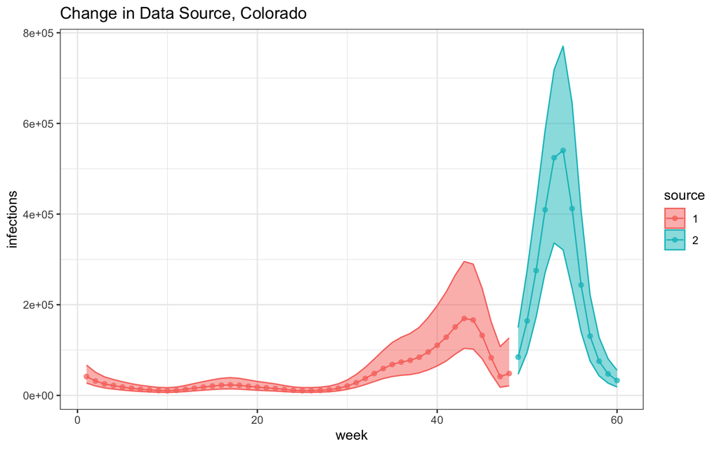

```r
covidestim <- readRDS(
  paste0(
    here::here(),
    "/data/covidestim/covidestim_original_all.RDS"))

# join data from each source to include dates before and after 2021-12-02
covidestim <- covidestim %>%
  select(date, contains("infections"), state) %>%
  filter(date <= end_date & year(date) > 2020) %>%
  mutate(week = week(date), year = year(date)) %>%
  mutate(week = case_when(
    year == 2022 ~ week + 52,
    year == 2021 ~ week
  )) %>%
  bind_rows(last_weeks) %>%
  group_by(week, state, year) %>%
  summarize(across(contains("infections"), sum), date = min(date)) %>%
  ungroup()

# look at discontinuity for example
covidestim %>%
  filter(state == "Colorado") %>%
  mutate(source = ifelse(date <= ymd("2021-12-02"), "1", "2")) %>%
  ggplot(aes(x = week,
             y = infections,
             color = source,
             ymin = infections.lo,
             ymax = infections.hi)) +
  geom_ribbon(alpha = .5, aes(fill = source)) +
  geom_line() +
  geom_point(alpha = .7) +
  theme_bw() +
  labs(title = "Change in Data Source, Colorado")
```

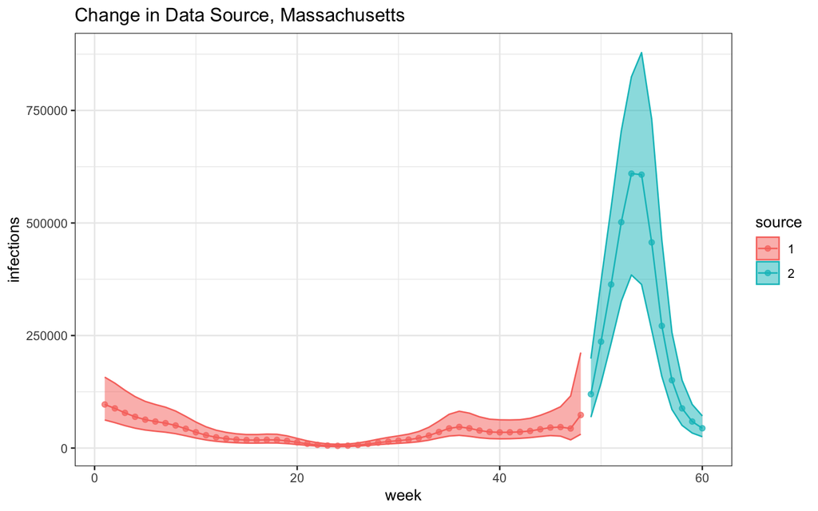

```r
covidestim %>%
  filter(state == "Massachusetts") %>%
  mutate(source = ifelse(date <= ymd("2021-12-02"), "1", "2")) %>%
  ggplot(aes(x = week,
             y = infections,
             color = source,
             ymin = infections.lo,
             ymax = infections.hi)) +
  geom_ribbon(alpha = .5, aes(fill = source)) +
  geom_line() +
  geom_point(alpha = .7) +
  theme_bw() +
  labs(title = "Change in Data Source, Massachusetts")
```

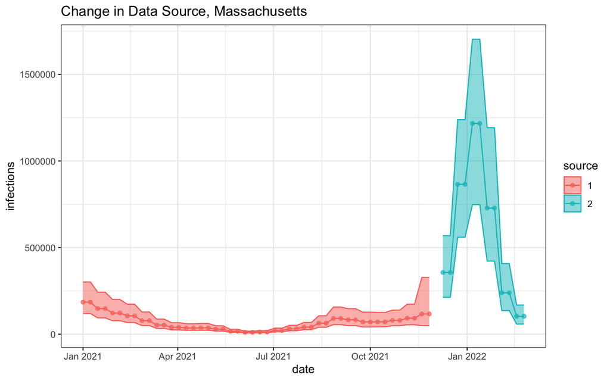

```r
###############
# add biweek
###############

num_weeks <- covidestim %>%
  pull(week) %>%
  unique() %>%
  length()

num_biweeks <- num_weeks/2

biweek <- tibble(biweek = c(rep(1:num_biweeks, 2))) %>%
  arrange(biweek)

biweek_to_week <- covidestim %>%
  select(week) %>%
  distinct() %>%
  arrange(week) %>%
  cbind(biweek =biweek)

# calculate biweekly sums
covidestim_biweekly <- covidestim %>%
  left_join(biweek_to_week) %>%
  group_by(biweek, state)  %>%
  mutate(across(
    contains("infections"),
    sum)) %>%
  ungroup()


covidestim_biweekly %>%
  select(-week) %>%
  filter(state == "Massachusetts") %>%
  mutate(source = ifelse(date <= ymd("2021-12-02"), "1", "2")) %>%
  ggplot(aes(x = date,
             y = infections,
             color = source,
             ymin = infections.lo,
             ymax = infections.hi)) +
  geom_ribbon(alpha = .5, aes(fill = source)) +
  geom_line() +
  geom_point(alpha = .7) +
  theme_bw() +
  labs(title = "Change in Data Source, Massachusetts")
```

```r
# add state codes
statecodes <- read_csv(paste0(
  here::here(),
  "/data/demographic/statecodes.csv")) %>%
  rename(state_name = state,
         state = code) %>%
  select(-abbrev)

covidestim_biweekly %>%
  rename(state_name = state) %>%
  left_join(statecodes) %>%
  saveRDS(paste0(
    here::here(),
    "/data/covidestim/covidestim_biweekly_all_states.RDS"))
```

## Covidestim All States (County Level)

```r
# if legacy file does not exist, acquire it from link
if(!file.exists(
  paste0(
      here::here(),
      "/data/covidestim/covidestim_county_estimates.RDS"))) {

  legacy_link <- "https://covidestim.s3.us-east-2.amazonaws.com/latest/estimates.csv"

  estimates_legacy <- read_csv(legacy_link) %>%
    select(fips, date, infections)

  saveRDS(
    estimates_legacy,
    paste0(
      here::here(),
      "/data/covidestim/covidestim_county_estimates.RDS"))
}
```

```r
county_estimates_path <- paste0(
  here::here(),
  "/data/covidestim/covidestim_county_estimates.RDS")

covidestim_county <- readRDS(county_estimates_path) %>%
  filter(date <= end_date &  year(date) > 2020) %>%
  mutate(week = week(date),
         year = year(date)) %>%
  mutate(week = case_when(
    year == 2022 ~ week + 52,
    year == 2021 ~ week
  ))


num_weeks <- covidestim_county %>%
  pull(week) %>%
  unique() %>%
  length()

num_biweeks <- num_weeks/2

biweek <- tibble(biweek = c(rep(1:num_biweeks, 2))) %>%
  arrange(biweek)

biweek_to_week <- covidestim_county %>%
  select(week) %>%
  distinct() %>%
  arrange(week) %>%
  cbind(biweek =biweek)
```

```r
############################################
# SUM FOR EACH BIWEEK IN EACH COUNTY
############################################


covidestim_biweekly_all_counties <- covidestim_county %>%
  left_join(biweek_to_week) %>%
  group_by(biweek, fips)  %>%
  mutate(across(contains("infections"), sum)) %>%
  ungroup()

covidestim_biweekly_all_counties %>%
  head()
```

| fips | date | infections | week | year | biweek |
| --- | --- | --- | --- | --- | --- |
| 01041 | 2021-01-01 | 522.7319 | 1 | 2021 | 1 |
| 01041 | 2021-01-02 | 522.7319 | 1 | 2021 | 1 |
| 01041 | 2021-01-03 | 522.7319 | 1 | 2021 | 1 |
| 01041 | 2021-01-04 | 522.7319 | 1 | 2021 | 1 |
| 01041 | 2021-01-05 | 522.7319 | 1 | 2021 | 1 |
| 01041 | 2021-01-06 | 522.7319 | 1 | 2021 | 1 |

```r
covidestim_biweekly_all_counties %>%
  saveRDS(file = paste0(
    here::here(),
    "/data/covidestim/covidestim_biweekly_all_counties.RDS"))
```

# State-level Cases

PCR test results at the state-level from healthdata.gov endpoint [here](https://healthdata.gov/dataset/COVID-19-Diagnostic-Laboratory-Testing-PCR-Testing/j8mb-icvb).

```r
dates <- readRDS(paste0(here::here(),
                 "/data/date_to_biweek.RDS"))


# PAGE: https://www2.census.gov/programs-surveys/popest/datasets/2010-2019/state/detail/
state_population_link <- "https://www2.census.gov/programs-surveys/popest/datasets/2010-2019/state/detail/SCPRC-EST2019-18+POP-RES.csv"
state_pop <- read_csv(state_population_link)

saveRDS(state_pop, paste0(
  here::here(),
  "/data/demographic/state_pop.RDS"))

statecodes <- read_csv(paste0(
  here::here(),
  "/data/demographic/statecodes.csv"))

state_pop <- state_pop %>%
  left_join(statecodes, by = c("NAME" = "state")) %>%
  select(population = POPESTIMATE2019,
         state = code) %>%
  filter(!is.na(state))
```

```r
# split into two queries to ensure we obtain all data with the API limit

dat <- httr::GET(URLencode(
  paste0("https://healthdata.gov/resource/j8mb-icvb.json?",
  "$where=date between '2020-12-30T12:00:00' and '2021-10-15T12:00:00'&$limit=50000")))

cdc1 <-jsonlite::fromJSON(
      httr::content(dat,
                    as = "text",
                    encoding = "UTF-8")) %>%
  as_tibble()


dat2 <- httr::GET(URLencode(
  paste0("https://healthdata.gov/resource/j8mb-icvb.json?",
  "$where=date between '2021-10-15T14:00:00' and '2022-02-25T14:00:00'&$limit=50000")))


cdc2 <-jsonlite::fromJSON(
      httr::content(dat2,
                    as = "text",
                    encoding = "UTF-8")) %>%
  as_tibble()


cdc <- bind_rows(cdc1, cdc2) %>%
  mutate(date = ymd(substr(date,1,10))) %>%
  mutate(across(c(new_results_reported), as.numeric)) %>%
  filter(!state %in% c("MP", "AS", "GU", "PR", "VI", "MH"))

# overall_outcome is the outcome of the test (Inconclusive, Negative, or Positive)
# new_results_reported is the number with the given outcome
cdc_pos <- cdc %>%
  select(-c(fema_region, total_results_reported)) %>%
  pivot_wider(names_from = c("overall_outcome"),
              values_from = c("new_results_reported")) %>%
  mutate(total = Inconclusive + Negative + Positive) %>%
  rename_with(tolower) %>%
  select(state, positive, total, date)

saveRDS(cdc_pos, paste0(here::here(),
                        "/data/state_level/tests_daily_all_states.RDS"))



cdc_pos %>%
  left_join(dates) %>%
  filter(!is.na(biweek)) %>%
  group_by(biweek, state) %>%
  mutate(positive = sum(positive, na.rm=TRUE),
         total = sum(total, na.rm = TRUE)) %>%
  ungroup() %>%
  mutate(posrate = positive/total) %>%
  left_join(state_pop) %>%
  saveRDS(paste0(here::here(),
                 "/data/state_level/tests_biweekly_all_states.RDS"))
```

# State-level Cases (JHU)

```r
jhu <- read_csv('https://raw.githubusercontent.com/govex/COVID-19/master/data_tables/testing_data/time_series_covid19_US.csv')



jhu %>%
  mutate(date=as_date(date, format= "%m/%d/%Y")) %>%
  filter(date >= "2021-03-03" & date <= "2022-03-02") %>%
  left_join(dates) %>%
  arrange(date) %>%
 # mutate(across(where(is.numeric), abs)) %>%
  mutate(people_viral_positive = people_viral_positive - lag(people_viral_positive, n = 1),
         people_viral_total = people_viral_total - lag(people_viral_total, n = 1)) %>%
#  filter(people_viral_positive < people_viral_total) %>%
  group_by(biweek,state) %>%
   # mutate(across(where(is.numeric), abs)) %>%
  mutate(across(c(people_viral_positive,people_viral_total), sum, na.rm=TRUE)) %>%
  select(date, biweek, people_viral_positive, people_viral_total, state) %>%
  group_by(state) %>%
  summarize(n=n_distinct(biweek))



dates <- readRDS(here('data/date_to_biweek.RDS'))

library(slider)

state_testing <- jhu %>%
  mutate(date=as_date(date, format= "%m/%d/%Y")) %>%
  filter(date >= "2021-02-26" & date <= "2022-02-25") %>%
  group_by(state) %>%
  arrange(state, date) %>%
 # mutate(across(where(is.numeric), abs)) %>%
  mutate(people_viral_positive = people_viral_positive - lag(people_viral_positive, n = 1, order_by=date),
         people_viral_total = people_viral_total - lag(people_viral_total, n = 1,  order_by=date),
         ) %>%
  mutate(people_viral_positive = ifelse(people_viral_positive < 0, NA,people_viral_positive),
         people_viral_total = ifelse(people_viral_total < 0, NA,people_viral_total),
  people_viral_positive_roll = slide_dbl(people_viral_positive, mean, .before=4, .after =4),
         people_viral_total_roll = slide_dbl(people_viral_total, mean, .before=4, .after =4),
         #  people_viral_positive = ifelse(is.na(people_viral_positive) | people_viral_positive==0,
         #                                 people_viral_positive_roll,
         #                                 people_viral_positive),
         # people_viral_total = ifelse(is.na(people_viral_total) | people_viral_total==0,
         #                             people_viral_total_roll,
         #                             people_viral_total)
  ) %>%
  left_join(dates) %>%
#  filter(people_viral_positive < people_viral_total) %>%
  group_by(biweek,state) %>%
   # mutate(across(where(is.numeric), abs)) %>%
  mutate(across(c(people_viral_positive,people_viral_total),  function(x) sum(x, na.rm = FALSE))) %>%
  mutate(has_both = !is.na(people_viral_positive) & !is.na(people_viral_total)) %>%
  select(biweek, people_viral_positive, people_viral_total, state, has_both)  %>%
  distinct() %>%
  ungroup()

state_testing %>%
  filter(has_both) %>%
  filter(biweek >=6)


states_keep <- state_testing %>%
  mutate(has_both = people_viral_positive > 0 & people_viral_total >0) %>%
  mutate(people_viral_total = ifelse(people_viral_total ==0, NA,  people_viral_total ),
         people_viral_total = ifelse(people_viral_positive ==0, NA,  people_viral_total )) %>%
  filter(has_both) %>%
  group_by(state)%>%
  summarize(n=n_distinct(biweek)) %>%
  filter(n >20)

state_testing %>%
  filter(biweek <28) %>%
  ggplot(aes(x=biweek, y = people_viral_positive/people_viral_total)) +
  geom_line() +
  facet_wrap(~state)


state_testing <- state_testing %>%
  group_by(state) %>%
  arrange(state,biweek) %>%
  mutate(pos_roll =slide_dbl(people_viral_positive, mean, .before=3, .after =2),
         total_roll =slide_dbl(people_viral_total, mean, .before=3, .after =2) ) %>%
  ungroup() %>%
  mutate(people_viral_total = ifelse(people_viral_total < people_viral_positive,
                                     total_roll,
                                     people_viral_total),
         people_viral_positive = ifelse(people_viral_total < people_viral_positive,
                                     pos_roll,
                                     people_viral_positive))  %>%
#  filter(people_viral_total < people_viral_positive) %>%
  mutate(people_viral_total = ifelse(people_viral_total < people_viral_positive,
                                     NA,
                                     people_viral_total),
         people_viral_positive = ifelse(people_viral_total < people_viral_positive,
                                     NA,
                                     people_viral_positive) ) %>%
  select(state, positive = people_viral_positive, total = people_viral_total, biweek) %>%
  mutate(posrate= positive/total) %>%
  filter(!is.na(positive) & !is.na(total) & !is.na(posrate)) %>%
  filter(state %in% states_keep$state) %>%
  left_join(state_pop)

state_all_biweeks <- state_testing %>% select(biweek, positive,state,population) %>%
  pivot_wider(names_from = biweek, values_from=positive) %>%
  pivot_longer(cols =3:ncol(.), values_to="positive", names_to="biweek") %>%
  mutate(biweek=as.integer(biweek)) %>%
  select(-positive)

state_testing <- state_testing %>%
  right_join(state_all_biweeks) %>%
  group_by(state) %>%
  arrange(biweek) %>%
  mutate(pos_roll =slide_dbl(positive, mean, na.rm=TRUE, .before=2, .after =2),
         total_roll =slide_dbl(total, mean, na.rm = TRUE, .before=2, .after =2)) %>%
  mutate(positive= ifelse(is.na(positive), pos_roll, positive),
         total = ifelse(is.na(total), total_roll, total)) %>%
  mutate(posrate=positive/total)

state_testing %>%
  filter(!state %in% c("MP", "AS", "GU", "PR", "VI", "MH")) %>%
   saveRDS(paste0(here::here(),
                 "/data/state_level/tests_biweekly_all_states_JHU.RDS"))
```

# County-level Cases

## Michigan

```r
county_fips <- read_tsv(paste0(
  here::here(),
  "/data/demographic/county_fips.tsv")) %>%
  dplyr::rename_with(.cols =everything(), tolower)




###############################
# MICHIGAN BIWEEKLY DATA
###############################


if(!file.exists(paste0(here::here(),
                     "/data/county_level/mi/mi_county_original.RDS"))) {
  link <- paste0("https://www.michigan.gov/coronavirus/-/media/Project/Websites/coronavirus/",
                 "Michigan-Data/09-27-2022/Datasets/Diagnostic-Tests-by-Result-and-County-2022-09-27.xlsx?",
                 "rev=7ba61151dcff4b038e33ea9ead95137c&hash=6C1AA97E93A30A3C1F10171233FDF31A")
  httr::GET(link, httr::write_disk(tf <- tempfile(fileext = ".xlsx")))
  df <- readxl::read_excel(tf)
  saveRDS(df, file = paste0(
    here::here(),
    "/data/county_level/mi/mi_county_original.RDS"))
}


counts_raw <- readRDS(paste0(
  here::here(),
  "/data/county_level/mi/mi_county_original.RDS"))

# basic reformatting; join fips code and population
counts_raw <- counts_raw %>%
  mutate(week = week(MessageDate),
         date = ymd(MessageDate)) %>%
  dplyr::rename_with(.cols =everything(), tolower) %>%
  mutate(state = "MI") %>%
  left_join(county_fips,
            by = c("county"="name",
                   "state" = "state")) %>%
  select(-messagedate) %>%
  left_join(population_2019, by = c("fips" = "fips_code"))

counts_raw %>%
  saveRDS(., file =  paste0(
    here::here(),
  "/data/county_level/mi/mi_county_daily.RDS"))


county <- counts_raw %>%
  mutate(
    week = week(date),
    year = year(date)) %>%
  filter(year > 2020 & date <= end_date) %>%
  mutate( week = case_when(
    year == 2021 ~ week,
    year == 2022 ~ week + 52)) %>%
  select(fips, county, positive,
         date, total, week,
         negative, population) %>%
  mutate(state = "MI")



######################
# ADD BIWEEK
######################
num_weeks <- unique(county$week) %>%
  length()

num_biweeks <- num_weeks/2

biweek <- tibble(biweek = c(rep(1:num_biweeks, 2))) %>%
  arrange(biweek)

biweek_to_week <- county %>%
  select(week) %>%
  distinct() %>%
  arrange(week) %>%
  cbind(biweek =biweek)

county_biweekly <- county %>%
  left_join(biweek_to_week) %>%
  group_by(biweek, fips)  %>%
  mutate(across(c(total,positive, negative),
                 sum)) %>%
  ungroup() %>%
  mutate(posrate = positive/ total) %>%
  select(-week) %>%
  filter(!is.na(fips))


county_biweekly %>%
  select(biweek,date) %>%
    distinct() %>%
  saveRDS(paste0(here::here(),
                 "/data/date_to_biweek.RDS"))

county_biweekly %>%
  select(-date) %>%
  distinct() %>%
  saveRDS(paste0(here::here(),
               "/data/county_level/mi/mi_county_biweekly.RDS"))
```

## Massachusetts

Obtain data from the webpage [here](https://www.mass.gov/info-details/archive-of-covid-19-cases-in-massachusetts). A downloaded version of this webpage and data downloaded from a link it contains (downloaded Feb 18, 2023) is included in this repository.

```r
county_fips <- read_tsv(paste0(
  here::here(),
  "/data/demographic/county_fips.tsv")) %>%
  dplyr::rename_with(.cols =everything(), tolower)


url_2019 <- "https://www2.census.gov/programs-surveys/popest/datasets/2010-2019/counties/totals/co-est2019-alldata.csv"
population_2019 <- read_csv(url_2019) %>%
  mutate(fips_code = paste0(STATE, COUNTY)) %>%
  select(fips_code,
         population = POPESTIMATE2019,
         county_name = CTYNAME)
```

```r
mass_html_page <- paste0(
  here::here(),
  "/data/county_level/ma/archived_webpage_mass_cases.html")

# SCRAPE LINKS FROM HTML
all_links <- tibble(lines = c(readLines(mass_html_page))) %>%
  filter(grepl("/doc/covid-19-raw-data-", lines)) %>%
  # extract the part in quotes
  mutate(lines = str_extract(lines, '".*."'))%>%
  # remove double quotes
  mutate(lines = gsub('"', "", lines)) %>%
  # remove any text before the www.mass.gov part of the link
  mutate(lines = gsub(".*www.mass.gov", "", lines)) %>%
  mutate(link = paste0("https://www.mass.gov", lines)) %>%
  pull(link)



read_data <- function(link) {
  httr::GET(link, httr::write_disk(tf <- tempfile(fileext = ".xlsx")))
  df <- readxl::read_excel(tf, sheet = "County_Weekly")

  df %>%
    select(contains("date"),
           total = `Total Tests (Last 14 days)`,
           positive = `Total Positive Tests (Last 14 days)`,
           county_name =County) %>%
    mutate( negative = total - positive,
            state = "MA")

}

# take the most recent; will filter to only include needed dates
file_link <- all_links[1]

if(!file.exists(paste0(
    here::here(),
    "/data/county_level/ma/ma_county_original.RDS"))) {

  ma_data <- read_data(file_link)
  ma_data %>%
  saveRDS(paste0(
    here::here(),
    "/data/county_level/ma/ma_county_original.RDS"))


}
```

```r
data_ma <- readRDS(
  paste0(
    here::here(),
    "/data/county_level/ma/ma_county_original.RDS"))

# Dukes and Nantucket counties are combined
data_ma$county_name %>% unique()
```

```
##  [1] "All of Massachusetts"         "Barnstable County"
##  [3] "Berkshire County"             "Bristol County"
##  [5] "Dukes County"                 "Dukes and Nantucket Counties"
##  [7] "Essex County"                 "Franklin County"
##  [9] "Hampden County"               "Hampshire County"
## [11] "Middlesex County"             "Nantucket County"
## [13] "Norfolk County"               "Plymouth County"
## [15] "Suffolk County"               "Unknown County"
## [17] "Worcester County"
```

```r
# only NAs are from counties that were combined
data_ma %>%
  filter(is.na(total) | is.na(positive)) %>%
  pull(county_name) %>%
  unique()
```

```
## [1] "Dukes County"     "Nantucket County"
```

```r
data_ma <- data_ma %>%
  filter(!(is.na(total) | is.na(positive)))

together <- county_fips %>%
  filter(name == "Dukes" | name == "Nantucket") %>%
  pull(fips) %>%
  paste0(collapse = ",")

##################################################################
# add Dukes and Nantucket county populations
# since their test numbers are combined
##################################################################
grouped_counties_fips <- county_fips %>%
  filter(name == "Dukes" | name == "Nantucket") %>%
  pull(fips)

county_fips <- county_fips %>%
  filter(!(fips %in% grouped_counties_fips)) %>%
  bind_rows(tibble(name = "Dukes and Nantucket",
                   fips = paste0(grouped_counties_fips,
                                 collapse=","),
                   state = "MA"))


# sum populations for grouped counties
population_2019 <- population_2019 %>%
  mutate(fips_code = ifelse(fips_code %in% grouped_counties_fips,
                            paste0(grouped_counties_fips,
                                 collapse=","),
                            fips_code)) %>%
  group_by(fips_code) %>%
  summarize(population = sum(population))
```

```r
data_ma <- data_ma %>%
  rename(report_date = `Report Date`,
         start_period_date = `Start Date`,
         end_period_date = `End Date`)%>%
  filter(!county_name %in% c("All of Massachusetts",
                             "Unknown County")) %>%
  mutate(year = year(start_period_date),
         week = week(start_period_date)) %>%
  filter(year> 2020 & start_period_date <= end_date) %>%
  mutate( week = case_when(
    year == 2021 ~ week,
    year == 2022 ~ week + 52)) %>%
  mutate(across(contains("date"),ymd))


# add fips
data_ma <- data_ma %>%
  mutate(county_name = gsub(" County", "", county_name),
         county_name = gsub(" Counties", "", county_name),
         county_name = trimws(county_name)) %>%
  left_join(county_fips,
            by = c("state"="state", "county_name"="name"))

# note that dates are overlapping, so remove the duplicates
# so that we have non-overlapping two-week intervals
data_ma %>%
  select(start_period_date, end_period_date, week) %>%
  distinct() %>%
  head(n = 30)
```

| start_period_date | end_period_date | week |
| --- | --- | --- |
| 2021-01-03 | 2021-01-16 | 1 |
| 2021-01-10 | 2021-01-23 | 2 |
| 2021-01-17 | 2021-01-30 | 3 |
| 2021-01-24 | 2021-02-06 | 4 |
| 2021-01-31 | 2021-02-13 | 5 |
| 2021-02-07 | 2021-02-20 | 6 |
| 2021-02-14 | 2021-02-27 | 7 |
| 2021-02-21 | 2021-03-06 | 8 |
| 2021-02-28 | 2021-03-13 | 9 |
| 2021-03-07 | 2021-03-20 | 10 |

[output cut: 20 more lines]

```r
# note that dates are overlapping, so remove the duplicates
startdate_to_biweek <- data_ma %>%
  filter(!week %% 2 ==0) %>%
  select(-week) %>%
  select(start_period_date) %>%
  distinct() %>%
  arrange(start_period_date) %>%
  mutate(biweek = row_number())

# note that summing by biweek is not needed because structure is already in
# 2 week interval format
data_ma  <- data_ma %>%
  filter(!week %% 2 ==0) %>%
  left_join(startdate_to_biweek) %>%
  select(-c(week, end_period_date,report_date)) %>%
  left_join(population_2019, by = c("fips" = "fips_code")) %>%
  rename(date = start_period_date) %>%
  mutate(posrate = positive/total)


data_ma %>%
  saveRDS(
    paste0(here::here(),
           "/data/county_level/ma/ma_county_biweekly.RDS"))
```

# Hospitalizations

## State-level Hospitalizations

Hospitalization data from the healthdata.gov endpoint [here](https://dev.socrata.com/foundry/healthdata.gov/g62h-syeh).

```r
##### WEEKLY
# https://dev.socrata.com/foundry/healthdata.gov/g62h-syeh
hosp <- httr::GET(URLencode(
  paste0("https://healthdata.gov/resource/g62h-syeh.json?",
  "$where=date between '2020-12-31T12:00:00' and '2022-02-25T14:00:00'&$",
  "select=deaths_covid,date,percent_of_inpatients_with_covid,",
  "inpatient_beds_used_covid,inpatient_beds_used,state&$limit=50000")))

hosp <-jsonlite::fromJSON(
  httr::content(hosp,
                as="text",
                encoding = "UTF-8")) %>%
  as_tibble()

hosp <- hosp %>%
  # reformat dates from 2021-01-01T00:00:00.000 format
  # to date foramt
  mutate(date = gsub("T.*", "",date),
         date = as.Date(date, format = "%Y-%m-%d"),
         week = week(date)) %>%
  mutate(across(-c(date,state), as.numeric))

hosp <- hosp %>%
  mutate(
    year = year(date)) %>%
  mutate(across(-c(date,state), as.numeric)) %>%
  mutate(week = case_when(
    year == 2021 ~ week,
    year == 2022 ~ week + 52
  ))


num_weeks <- unique(hosp$week) %>%
  length()

num_biweeks <- num_weeks/2

biweek <- tibble(biweek = c(rep(1:num_biweeks, 2))) %>%
  arrange(biweek)

biweek_to_week <- hosp %>%
  select(week) %>%
  distinct() %>%
  arrange(week) %>%
  cbind(biweek =biweek)

####################################
#save biweekly hospitalizations
####################################
hosp_biweekly <- hosp %>%
  left_join(biweek_to_week) %>%
  group_by(biweek, state) %>%
  mutate(across(c(deaths_covid,
                  inpatient_beds_used_covid,
                  inpatient_beds_used),
                sum))

hosp_biweekly %>%
  head(n= 30)
```

| deaths_covid | date | percent_of_inpatients_with_covid | inpatient_beds_used_covid | inpatient_beds_used | state | week | year | biweek |
| --- | --- | --- | --- | --- | --- | --- | --- | --- |
| 126 | 2021-01-01 | 0.20654122 | 6277 | 32659 | RI | 1 | 2021 | 1 |
| 6952 | 2021-01-01 | 0.40378818 | 321381 | 770918 | CA | 1 | 2021 | 1 |
| 528 | 2021-01-01 | 0.26447595 | 28963 | 109713 | OK | 1 | 2021 | 1 |
| 508 | 2021-01-01 | 0.14749321 | 30259 | 212068 | MA | 1 | 2021 | 1 |
| 13 | 2021-01-01 | 0.09219858 | 1128 | 12205 | AK | 1 | 2021 | 1 |
| 183 | 2021-01-01 | 0.24401753 | 9999 | 43625 | NM | 1 | 2021 | 1 |
| 42 | 2021-01-01 | 0.17696268 | 3521 | 22599 | SD | 1 | 2021 | 1 |
| 547 | 2021-01-01 | 0.23085806 | 37076 | 167550 | IN | 1 | 2021 | 1 |
| 45 | 2021-01-01 | 0.09923274 | 2928 | 28332 | MT | 1 | 2021 | 1 |
| 889 | 2021-01-01 | 0.20226973 | 53847 | 253285 | NC | 1 | 2021 | 1 |

[output cut: 20 more lines]

```r
hosp_biweekly %>%
  saveRDS(paste0(here::here(),
                 "/data/state_level/hosp_biweekly_all_states.RDS"))
```

## County-level Hospitalizations

Hospitalization data is from the Covidestim data sources repository [here](https://github.com/covidestim/covidestim-sources); details available under the *Hospitalization data pipeline section* of their Readme. Briefly, they use HHS facility-level hospitalization data and using geographic information to aggregate by county.

Values between 1 and 3 are censored, so the Covidestim developers included two estimates to bound the possible values:

- `admissionsAdultsConfirmed_min`: The smallest the outcome could be - all censored values, which each represent a possible range of 1-3, will be resolved to 1.
- `admissionsAdultsConfirmed_max:` censored values taken to be 3

```r
dates <- readRDS(paste0(here::here(),
                 "/data/date_to_biweek.RDS"))

county_hosp <- readRDS(paste0(
    here::here(),
    "/data/county_level/hosp/hhs-hospitalizations-by-county.RDS")) %>%
  filter(year(weekstart) >= 2021 & weekstart <= end_date)

county_hosp %>% head()
```

| fips | weekstart | admissionsAdultsConfirmed | admissionsAdultsSuspected | admissionsPedsConfirmed | admissionsPedsSuspected | averageAdultInpatientsConfirmed | averageAdultInpatientsConfirmedSuspected | averageAdultICUPatientsConfirmed | averageAdultICUPatientsConfirmedSuspected | covidRelatedEDVisits | admissionsAdultsConfirmed_min | admissionsAdultsSuspected_min | admissionsPedsConfirmed_min | admissionsPedsSuspected_min | averageAdultInpatientsConfirmed_min | averageAdultInpatientsConfirmedSuspected_min | averageAdultICUPatientsConfirmed_min | averageAdultICUPatientsConfirmedSuspected_min | covidRelatedEDVisits_min | admissionsAdultsConfirmed_max | admissionsAdultsSuspected_max | admissionsPedsConfirmed_max | admissionsPedsSuspected_max | averageAdultInpatientsConfirmed_max | averageAdultInpatientsConfirmedSuspected_max | averageAdultICUPatientsConfirmed_max | averageAdultICUPatientsConfirmedSuspected_max | covidRelatedEDVisits_max | admissionsAdultsConfirmed_max2 | … |
| --- | --- | --- | --- | --- | --- | --- | --- | --- | --- | --- | --- | --- | --- | --- | --- | --- | --- | --- | --- | --- | --- | --- | --- | --- | --- | --- | --- | --- | --- | --- |
| 01001 | 2021-01-01 | 43 | -999999 | -999999 | -999999 | -999999 | -999999 | 5 | 5 | 96 | 43 | 19 | 0 | 0 | 40 | 42 | 5 | 5 | 96 | 43 | 19 | 0 | 0 | 41 | 42 | 5 | 5 | 96 | 43 | … |
| 01001 | 2021-01-08 | 34 | -999999 | 0 | -999999 | -999999 | -999999 | 6 | 6 | 57 | 34 | 16 | 0 | 0 | 42 | 43 | 6 | 6 | 57 | 34 | 17 | 0 | 0 | 42 | 43 | 6 | 6 | 57 | 34 | … |
| 01001 | 2021-01-15 | -999999 | -999999 | -999999 | -999999 | -999999 | -999999 | 7 | 7 | 72 | 31 | 12 | 0 | 0 | 37 | 37 | 7 | 7 | 72 | 31 | 12 | 0 | 0 | 37 | 37 | 7 | 7 | 72 | 31 | … |
| 01001 | 2021-01-22 | -999999 | -999999 | -999999 | -999999 | -999999 | -999999 | -999999 | -999999 | 53 | 28 | 11 | 0 | 0 | 24 | 24 | 6 | 7 | 53 | 28 | 11 | 0 | 0 | 24 | 25 | 6 | 7 | 53 | 28 | … |
| 01001 | 2021-01-29 | -999999 | -999999 | -999999 | -999999 | -999999 | -999999 | -999999 | -999999 | 39 | 22 | 14 | 1 | 0 | 23 | 23 | 5 | 5 | 39 | 22 | 14 | 3 | 0 | 23 | 23 | 5 | 5 | 39 | 22 | … |
| 01001 | 2021-02-05 | -999999 | -999999 | -999999 | -999999 | -999999 | -999999 | 5 | 5 | 47 | 27 | 13 | 0 | 0 | 21 | 21 | 5 | 5 | 47 | 27 | 13 | 0 | 0 | 21 | 21 | 5 | 5 | 47 | 27 | … |

```r
# sum by biweek
county_hosp <- county_hosp %>%
  select(fips,
         weekstart,
         admissionsAdultsConfirmed_max,
         admissionsAdultsConfirmed_min) %>%
  left_join(dates, by = c("weekstart"="date")) %>%
  rename(date=weekstart)%>%
  group_by(fips,biweek) %>%
  summarize(across(contains("admissions"), sum),
            date = min(date)) %>%
  ungroup()

county_hosp %>% head()
```

| fips | biweek | admissionsAdultsConfirmed_max | admissionsAdultsConfirmed_min | date |
| --- | --- | --- | --- | --- |
| 01001 | 1 | 77 | 77 | 2021-01-01 |
| 01001 | 2 | 59 | 59 | 2021-01-15 |
| 01001 | 3 | 49 | 49 | 2021-01-29 |
| 01001 | 4 | 25 | 25 | 2021-02-12 |
| 01001 | 5 | 24 | 24 | 2021-02-26 |
| 01001 | 6 | 13 | 13 | 2021-03-12 |

```r
county_hosp %>%
  saveRDS(paste0(
    here::here(),
    "/data/county_level/hosp/hosp_biweekly_all_counties.RDS"))
```

# COVID-19 Trends and Impact Survey Data

Accessed through the [Covidcast API](https://cmu-delphi.github.io/delphi-epidata/api/covidcast-signals/fb-survey.html).

From the documentation:

- `smoothed_wtested_positive_14d`: positivity rate among those tested for COVID-19 in previous 14 days
- `smoothed_wscreening_tested_positive_14d`: positivity rate among those screened for COVID-19 without symptoms or known exposure

```r
screening_data_link <- paste0(
  "https://api.covidcast.cmu.edu/epidata/covidcast/?data_source=fb-survey",
  "&signal=smoothed_wscreening_tested_positive_14d,smoothed_wtested_positive_14d,smoothed_wcli",
  "&geo_type=state&time_type=day&time_values=20210320-20221212&geo_value=*")

fb_screening <- httr::GET(screening_data_link)

fb_symptoms <-jsonlite::fromJSON(
      httr::content(fb_screening,
                    as = "text",
                    encoding = "UTF-8"))$epidata %>%
   mutate(date = lubridate::ymd(time_value),
          week = lubridate::week(date),
          state = geo_value,
          value = value/100,
          stderr = stderr/100) %>%
  filter(date <= lubridate::ymd("2022-03-01")) %>%
  as_tibble()


fb_symptoms %>%
  saveRDS(paste0(
    here::here(),
    "/data/state_level/screeningpos_all_states.RDS"))
```

# Biobot Wastewater Data

```r
biobot_link <- "https://raw.githubusercontent.com/biobotanalytics/covid19-wastewater-data/master/wastewater_by_county.csv"

dates <- readRDS(here("data", "date_to_biweek.RDS"))

w_data <- read_csv(biobot_link)%>%
  filter(sampling_week >= ymd("2021-03-01") &  sampling_week <= ymd("2022-03-01")) %>%
  mutate(fips = as.character(fipscode)) %>%
  select(-fipscode)  %>%
  left_join(dates, by = c("sampling_week" = "date")) %>%
  group_by(fips, biweek, state,name) %>%
  summarize(mean_conc = mean(effective_concentration_rolling_average, na.rm= TRUE)) %>%
  ungroup()


saveRDS(w_data,
        here("data/county_level", "biobot_wastewater_county.RDS"))
```